# Battle Creek

Sadie Gill, Mark Tompkins

July 2020

## Future Data Improvements

None planned.

## Instream Spawning and Rearing Habitat

**Data Source:** [Thomas R. Payne & Associates 1995](https://s3-us-west-2.amazonaws.com/cvpiahabitat-r-package/cvpia-sit-model-inputs/Payne1995_BattleCreekIFIM.pdf) (pg C-1) and [Thomas R. Payne & Associates 1998](https://cvpiahabitat-r-package.s3-us-west-2.amazonaws.com/TRPA-1998-Task-1.pdf) (pg C-1)

The instream spawning and rearing habitat for Fall Run Chinook Salmon, Spring Run Chinook Salmon, and Steelhead in Battle Creek are based on data from Thomas R. Payne & Associates’ 1995 instream flow evaluations. The Winter Run in Battle Creek are based on the 1998 instream flow evaluations. The flow evaluations were conducted for the California Department of Fish and Wildlife. They uncovered relationships between flow and both suitable spawning habitat and suitable rearing habitat from seven study reaches in Battle Creek. For both species, the weighted usable area (WUA) data were consolidated from all mainstem reaches.

### Spawning and Rearing Data

The instream spawning and rearing habitat data described above for Fall Run Chinook Salmon (FR), Spring Run Chinook Salmon (SR), and Steelhead (ST) are combined for use in the Decision Support Model (DSM) in the following format. Units are in square feet per 1000 feet.

**Fall Run**

Header Descriptions: flow_cfs = flow in cubic feet per second, FR_spawn_wua = Fall Run Chinook Spawning WUA, FR_fry_wua = Fall Run Chinook Fry WUA, FR_juv_wua = Fall Run Chinook Juvenile WUA watershed = section of stream modeled for CVPIA SDM

| flow_cfs | FR_spawn_wua | FR_fry_wua | FR_juv_wua | watershed |
| --- | --- | --- | --- | --- |
| 8 | 130.33 | 15577.42 | 4951.72 | Battle Creek |
| 10 | 200.10 | 15410.91 | 5858.00 | Battle Creek |
| 12 | 275.77 | 15181.16 | 6704.73 | Battle Creek |
| 14 | 358.81 | 14928.81 | 7488.45 | Battle Creek |
| 16 | 435.23 | 14661.05 | 8211.50 | Battle Creek |
| 18 | 513.79 | 14371.35 | 8879.50 | Battle Creek |

*… with 30 more rows*

**Spring Run**

Header Descriptions: flow_cfs = flow in cubic feet per second, SR_spawn_wua = Spring Run Chinook Spawning WUA, SR_fry_wua = Spring Run Chinook Fry WUA, SR_juv_wua = Spring Run Chinook Juvenile WUA watershed = section of stream modeled for CVPIA SDM

| flow_cfs | SR_spawn_wua | SR_fry_wua | SR_juv_wua | watershed |
| --- | --- | --- | --- | --- |
| 8 | 614.98 | 15577.42 | 4951.72 | Battle Creek |
| 10 | 761.60 | 15410.91 | 5858.00 | Battle Creek |
| 12 | 897.95 | 15181.16 | 6704.73 | Battle Creek |
| 14 | 1034.54 | 14928.81 | 7488.45 | Battle Creek |
| 16 | 1177.36 | 14661.05 | 8211.50 | Battle Creek |
| 18 | 1312.89 | 14371.35 | 8879.50 | Battle Creek |

*… with 30 more rows*

**Steelhead**

Header Descriptions: flow_cfs = flow in cubic feet per second, ST_spawn_wua = Spring Run Chinook Spawning WUA, ST_fry_wua = Steelhead Chinook Fry WUA, SR_juv_wua = Steelhead Chinook Juvenile WUA, ST_adult_wua = Steelhead Adult Rearing WUA, watershed = section of stream modeled for CVPIA SDM

| flow_cfs | ST_spawn_wua | ST_fry_wua | ST_juv_wua | ST_adult_wua | watershed |
| --- | --- | --- | --- | --- | --- |
| 8 | 266.30 | 4612.27 | 13056.70 | 9122.98 | Battle Creek |
| 10 | 364.83 | 4289.54 | 13667.70 | 9728.00 | Battle Creek |
| 12 | 458.80 | 4035.90 | 14128.02 | 10253.11 | Battle Creek |
| 14 | 565.26 | 3809.16 | 14464.77 | 10711.28 | Battle Creek |
| 16 | 680.82 | 3588.96 | 14722.92 | 11113.88 | Battle Creek |
| 18 | 778.70 | 3409.46 | 14899.43 | 11459.39 | Battle Creek |

*… with 30 more rows*

**Winter Run**

Header Descriptions: flow_cfs = flow in cubic feet per second, WR_spawn_wua = Winter Run Chinook Spawning WUA, WR_fry_wua = Winter Run Chinook Fry WUA, WR_juv_wua = Winter Run Chinook Juvenile WUA watershed = section of stream modeled for CVPIA SDM

| flow_cfs | WR_spawn_wua | WR_fry_wua | WR_juv_wua | watershed |
| --- | --- | --- | --- | --- |
| 8 | 567.2981 | 11857.47 | 4126.819 | Battle Creek |
| 10 | 707.4497 | 11679.59 | 4923.229 | Battle Creek |
| 12 | 850.7454 | 11432.35 | 5712.370 | Battle Creek |
| 14 | 969.3630 | 11216.95 | 6354.508 | Battle Creek |
| 16 | 1066.4405 | 10985.86 | 6944.252 | Battle Creek |
| 18 | 1153.4530 | 10734.30 | 7473.724 | Battle Creek |

*… with 30 more rows*

### Spawning WUA

The following plot shows the spawning WUA in square feet per thousand feet for Fall Run Chinook Salmon, Steelhead, and Spring Run Chinook Salmon. These area per length rates are multiplied by the total spawning reach length mapped by the Science Integration Team (SIT) to estimate available habitat.

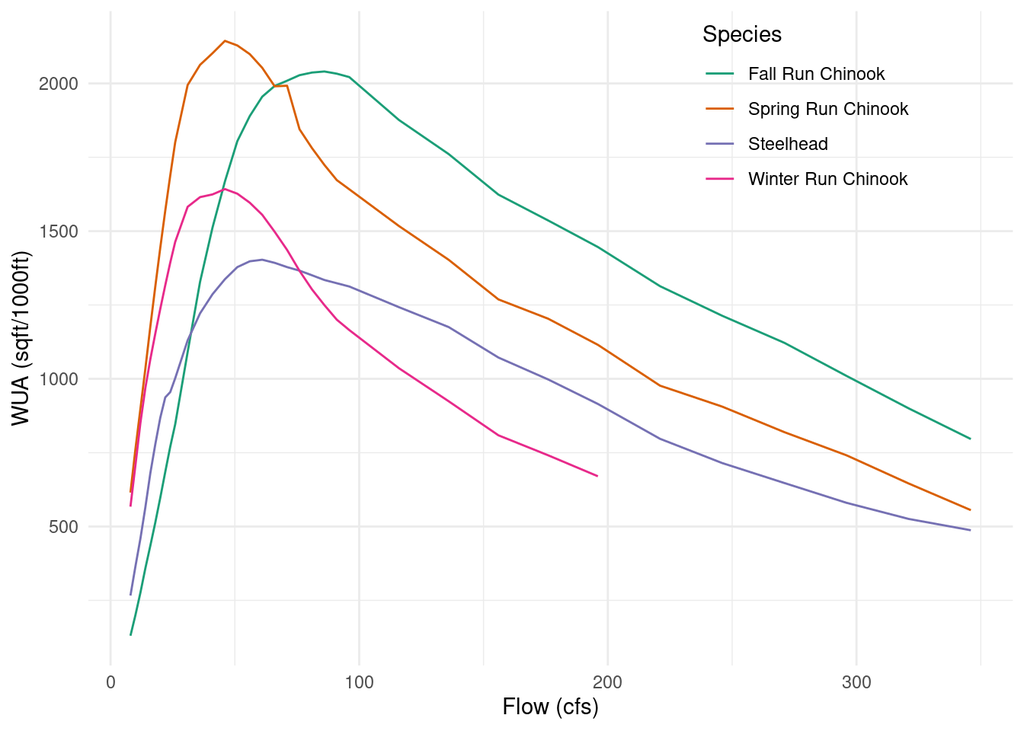

### Rearing WUA

The following plot shows the weighted usable rearing area in square feet per thousand feet for Fall Run Chinook Salmon and Steelhead fry and juvenile. These rates are multiplied by the total rearing reach length mapped by the SIT to estimate available habitat.

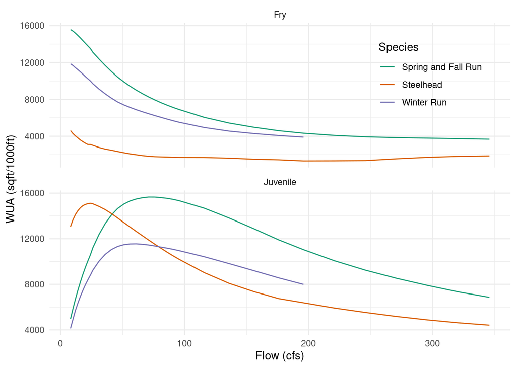

## Floodplain Rearing Habitat

**Data Source**: Scaled from a Deer Creek flow to floodplain area relationship generated with a [2D HEC-RAS hydraulic model](https://cvpiahabitat-r-package.s3.us-west-2.amazonaws.com/cvpia-sit-model-inputs/DeerCreek_2Dmodel_FlowWest_Final.pdf). See [Deer Creek HSI modeling documentation](http://cvpia-habitat-docs-markdown.s3-website-us-west-2.amazonaws.com/watershed/deer_creek.html) for more details.

### Fall Run

There was no watershed specific hydraulic modeling available for Battle Creek. A flow to inundated floodplain area relationship was generated for Battle Creek by scaling the flow to inundated floodplain area relationship for Deer Creek. This scaling used the ratio of mean flow from December to June between the modeled and unmodeled watershed. Flows and corresponding inundated floodplain areas per unit length were calculated for Battle Creek as 147% of Deer Creek. Of the entire mapped 5.9 miles rearing extent in Battle Creek, 5.9 miles were classified as low gradient and 0 miles were classified as high gradient based on a geomorphic analysis of long profile slopes and valley widths. The area per unit length was scaled by a factor of 0.1 for the high gradient extent. There was no scaling factor applied to the low gradient extent.

### Late Fall Run

There was no watershed specific hydraulic modeling available for Battle Creek. A flow to inundated floodplain area relationship was generated for Battle Creek by scaling the flow to inundated floodplain area relationship for Deer Creek. This scaling used the ratio of mean flow from December to June between the modeled and unmodeled watershed. Flows and corresponding inundated floodplain areas per unit length were calculated for Battle Creek as 147% of Deer Creek. Of the entire mapped 16.6 miles rearing extent in Battle Creek, 5.9 miles were classified as low gradient and 10.7 miles were classified as high gradient based on a geomorphic analysis of long profile slopes and valley widths. The area per unit length was scaled by a factor of 0.1 for the high gradient extent. There was no scaling factor applied to the low gradient extent.

### Winter Run

There was no watershed specific hydraulic modeling available for Battle Creek. A flow to inundated floodplain area relationship was generated for Battle Creek by scaling the flow to inundated floodplain area relationship for Deer Creek. This scaling used the ratio of mean flow from December to June between the modeled and unmodeled watershed. Flows and corresponding inundated floodplain areas per unit length were calculated for Battle Creek as 147% of Deer Creek. Of the entire mapped 18.5 miles rearing extent in Battle Creek, 5.9 miles were classified as low gradient and 12.6 miles were classified as high gradient based on a geomorphic analysis of long profile slopes and valley widths. The area per unit length was scaled by a factor of 0.1 for the high gradient extent. There was no scaling factor applied to the low gradient extent.

### Spring Run and Steelhead

There was no watershed specific hydraulic modeling available for Battle Creek. A flow to inundated floodplain area relationship was generated for Battle Creek by scaling the flow to inundated floodplain area relationship for Deer Creek. This scaling used the ratio of mean flow from December to June between the modeled and unmodeled watershed. Flows and corresponding inundated floodplain areas per unit length were calculated for Battle Creek as 147% of Deer Creek. Of the entire mapped 24.4 miles rearing extent in Battle Creek, 5.9 miles were classified as low gradient and 18.5 miles were classified as high gradient based on a geomorphic analysis of long profile slopes and valley widths. The area per unit length was scaled by a factor of 0.1 for the high gradient extent. There was no scaling factor applied to the low gradient extent.

## Floodplain Data

The areas represent total inundated area in acres.

Header Descriptions: flow_cfs = flow in cubic feet per second, FR_floodplain_acres = Fall Run Chinook floodplain acres, SR_floodplain_acres = Spring Run Chinook floodplain acres, WR_floodplain_acres = Winter Run floodplain acres, ST_floodplain_acres = Steelhead floodplain acres, LFR_floodplain_acres = Late Fall Run Chinook floodplain acres, watershed = section of stream modeled for CVPIA SDM

| flow_cfs | FR_floodplain_acres | SR_floodplain_acres | WR_floodplain_acres | ST_floodplain_acres | LFR_floodplain_acres | watershed |
| --- | --- | --- | --- | --- | --- | --- |
| 1325 | 0.00 | 0.00 | 0.00 | 0.00 | 0.00 | Battle Creek |
| 1473 | 4.22 | 7.18 | 5.13 | 7.18 | 5.00 | Battle Creek |
| 4418 | 60.38 | 102.72 | 73.37 | 102.72 | 71.44 | Battle Creek |
| 7363 | 103.65 | 176.32 | 125.94 | 176.32 | 122.62 | Battle Creek |
| 8836 | 118.93 | 202.32 | 144.51 | 202.32 | 140.70 | Battle Creek |

*… with 8 more rows*

## Floodplain Plot

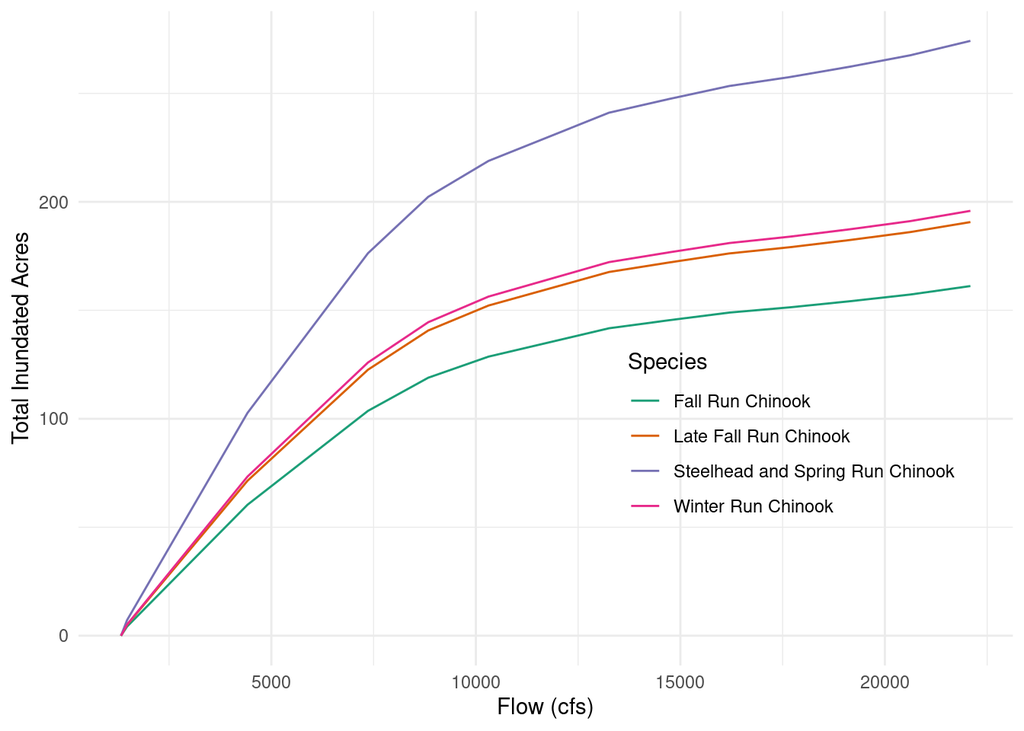